# Statistic Task

### Dunn’s Test for checking significant difference of Aphid Population by Treatment

```r
#Computing all pairwise average differences
Mean_Diff <-TukeyHSD(aov(aphid_population~treatment,Aphid_population_Apple))$treatment %>%
  data.frame() %>%rownames_to_column(.,var="Pairs") %>%
  mutate(Difference=round(diff,3)) %>%
  select(1,6)

#Calculating p-values for sinficance of average differences, using bonferroni method
options(scipen = 999)
dun_test <- dunnTest(aphid_population~treatment,Aphid_population_Apple,method="bonferroni")
#Creating table of results
Post_Hoc <- cbind(Mean_Diff,P_Values = round(dun_test$res[4],3))
# Creating Table
tab_df(Post_Hoc,title = "Table 4: Post-Hoc Aphid Population Apple by Treatment",digits = 3)
```

Table 4: Post-Hoc Aphid Population Apple by Treatment

| Pairs | Difference | P.adj |
| --- | --- | --- |
| FS1+Insect-FS1 | 2.163 | 0.270 |
| FS14-FS1 | 1.027 | 1.000 |
| FS14+Insect-FS1 | 1.827 | 1.000 |
| Insect-FS1 | 0.350 | 0.869 |
| NoTreatment-FS1 | -0.373 | 1.000 |
| FS14-FS1+Insect | -1.137 | 1.000 |
| FS14+Insect-FS1+Insect | -0.337 | 0.132 |
| Insect-FS1+Insect | -1.813 | 0.000 |
| NoTreatment-FS1+Insect | -2.537 | 0.006 |
| FS14+Insect-FS14 | 0.800 | 0.000 |
| Insect-FS14 | -0.677 | 0.011 |
| NoTreatment-FS14 | -1.400 | 0.000 |
| Insect-FS14+Insect | -1.477 | 0.000 |
| NoTreatment-FS14+Insect | -2.200 | 0.000 |
| NoTreatment-Insect | -0.723 | 1.000 |

The average difference in each pair is presented in above table, and Adjusted P-values (p-adj), are also presented in the last column. The Adjusted P-values are calculated using `Bonferroni` method, as we are conducting the multiple test.

However, the difference having adjusted p-value lower than `0.05`, are considered as significant difference. For example, the p-value of pair `FS14+Insect-FS14` is found to be less than `0.05`, hence this difference is significant and positive. It suggests that the Treatment `FS14+Insect` have higher value of Aphid Population Apple as compared to `FS14`.

### Plotting for visual comparisons

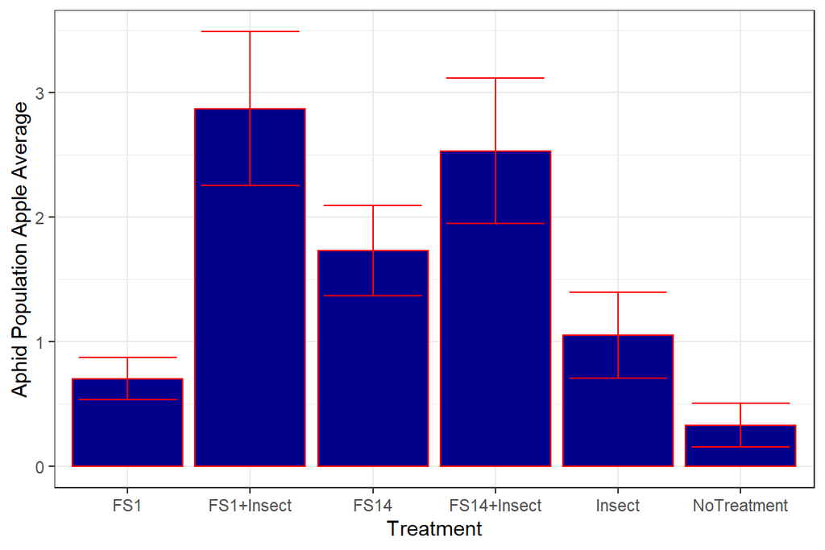

```r
##Boxplots
error_bars_Aphid_Population_Apple <- ggplot(Aphid_population_Apple,aes(treatment,aphid_population))+
  geom_bar(fill="darkblue",stat = "summary",fun="mean",col="red")+xlab("Treatment")+
  geom_errorbar(stat='summary', width=0.8,position = "dodge",col="red")+
  theme_bw()+ylab("Aphid Population Apple Average");error_bars_Aphid_Population_Apple
```

```r
#Save plot
ggsave("error_bars_Aphid_Population_Apple.tiff", units="in", width=10, height=5, dpi=300, compression = 'lzw')
```

## 3: Comparing the Aphid Mites Apple for each treatment

```r
# Mites_Apple data
Mites_Apple <- read_excel("Appletrees_insects_v2.xlsx",
                                sheet="Mites_apple")
```

### Descriptive statistics of Mites Total by Treatment

```r
Mites_Apple_mean <- data.frame(Mites_Apple %>%
                                  group_by(treatment) %>%
                                  summarise(Mean = mean(total_mites),
                                            SD = sd(total_mites),
                                            Minimum = min(total_mites),
                                            Maximum =max(total_mites)))
tab_df(Mites_Apple_mean,
       title = "Table 5: Descriptive Statistics of Mites Total Apple by Treatment")
```

Table 5: Descriptive Statistics of Mites Total Apple by Treatment

| treatment | Mean | SD | Minimum | Maximum |
| --- | --- | --- | --- | --- |
| FS1 | 22.58 | 49.67 | 0 | 361 |
| FS1+Insect | 24.46 | 61.53 | 0 | 364 |
| FS14 | 50.21 | 83.38 | 0 | 438 |
| FS14+Insect | 24.15 | 71.30 | 0 | 555 |
| Insect | 37.26 | 109.14 | 0 | 641 |
| NoTreatment | 34.37 | 76.99 | 0 | 515 |

For normality, we are conducting a Shapiro-Wilk normality test. The null and alternative hypotheses for this test are given below:

$H_0$: The distribution of Total Mites Apple is normal. $H_1$: The distribution of Total Mites Apple is not normal.

```r
normal_test <- shapiro.test(Mites_Apple$total_mites)
noquote("Shapiro-Wilk normality test")
```

```
## [1] Shapiro-Wilk normality test
```

```r
cat("Test Statistic (W) =", 0.50,"\n")
```

```
## Test Statistic (W) = 0.5
```

```r
cat("P-value <", 0.0001,"\n")
```

```
## P-value < 0.0001
```

The P-value of Shapiro-Wilk test is found to be lower than `0.0001`, which suggests that the null hypothesis of the “The distribution of Total Mites Apple is normal”, is rejected. Hence, the Aphid Total Mites Apple is not normal, and the Parametric test is not appropriate here.

Since, we need to compare the Total Mites by Treatments, and the treatment groups are more than two. Hence, a non-parametric test (Kruskal-Wallis Test) alternative to One-Way ANOVA, is appropriate to achieve the study purposes.

### Plotting Histogram for checking Shape

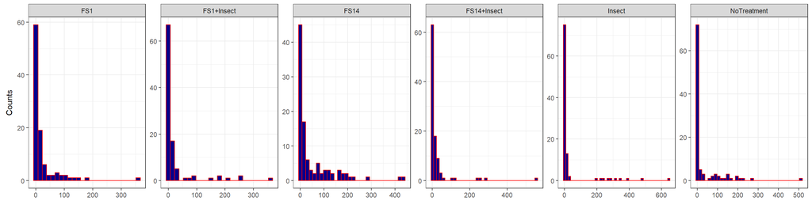

```r
#Converting treatment to factors
Mites_Apple$treatment <- as.factor(Mites_Apple$treatment)
##Boxplots
Hist_total_mites_Apple <- ggplot(Mites_Apple,aes(x=total_mites))+
  geom_histogram(fill="darkblue",col="red",binwidth = 15)+xlab("")+ylab("")+
  facet_wrap(treatment~.,scales = "free",ncol=7)+
  theme_bw()+ylab("Counts");Hist_total_mites_Apple
```

```r
#Save plot
ggsave("Hist_total_mites_Apple.tiff", units="in", width=15, height=5, dpi=300, compression = 'lzw')
```

Histograms suggesting that the shapes of distributions of the Total Mites Apple are different than each other, as some of them are highly skewed, and some of these are slightly skewed, and their variability is different than each other. Hence, the mean comparison through Kruskal Wallis test is appropriate here.

### Implementing Kruskal Wallis Test

The null and alternative hypotheses for this test are given below:

$H_0$: There is no difference in average Total Mites Apple by treatments. $H_1$: There is a difference in average Total Mites Apple by treatments.

```r
#Kruskal Wallis test
kstest3 <- kruskal.test(total_mites~treatment,Mites_Apple)
#Reporting results
noquote("Results of Kruskal-Wallis rank sum test")
```

```
## [1] Results of Kruskal-Wallis rank sum test
```

```r
cat("Kruskal-Wallis chi-squared =",18,"\n")
```

```
## Kruskal-Wallis chi-squared = 18
```

```r
cat("Degree of Freedom =",5,"\n")
```

```
## Degree of Freedom = 5
```

```r
cat("P-value =","0.003","\n")
```

```
## P-value = 0.003
```

It can be observed that the p-value of Kruskal-Wallis test is lower than `0.05` (level of significance). Hence, the null hypothesis will be rejected, and it is concluded that there is a significant difference in the average Total Mites Apple by treatments.

For comparing the average significant difference in each pair of treatments, we conducted Dunn’s Test, which is post-hoc test, and used when the null hypothesis if Kruskal-Wallis test is rejected. Also, for visual comparison, we have plotted the average and error-bars for Total Mites Apple by Treatments.

### Dunn’s Test for checking significant difference of Total Mites Apple by Treatment

```r
#Computing all pairwise average differences
Mean_Diff <-TukeyHSD(aov(total_mites~treatment,Mites_Apple))$treatment %>%
  data.frame() %>%rownames_to_column(.,var="Pairs") %>%
  mutate(Difference=round(diff,3)) %>%
  select(1,6)

#Calculating p-values for sinficance of average differences, using bonferroni method
options(scipen = 999)
dun_test <- dunnTest(total_mites~treatment,Mites_Apple,method="bonferroni")
#Creating table of results
Post_Hoc <- cbind(Mean_Diff,P_Values = round(dun_test$res[4],3))
# Creating Table
tab_df(Post_Hoc,title = "Table 6: Post-Hoc Total Mites Apple by Treatment",digits = 3)
```

Table 6: Post-Hoc Total Mites Apple by Treatment

| Pairs | Difference | P.adj |
| --- | --- | --- |
| FS1+Insect-FS1 | 1.880 | 1.000 |
| FS14-FS1 | 27.630 | 0.074 |
| FS14+Insect-FS1 | 1.570 | 0.542 |
| Insect-FS1 | 14.680 | 1.000 |
| NoTreatment-FS1 | 11.790 | 1.000 |
| FS14-FS1+Insect | 25.750 | 0.611 |
| FS14+Insect-FS1+Insect | -0.310 | 1.000 |
| Insect-FS1+Insect | 12.800 | 1.000 |
| NoTreatment-FS1+Insect | 9.910 | 0.008 |
| FS14+Insect-FS14 | -26.060 | 1.000 |
| Insect-FS14 | -12.950 | 1.000 |
| NoTreatment-FS14 | -15.840 | 1.000 |
| Insect-FS14+Insect | 13.110 | 0.002 |
| NoTreatment-FS14+Insect | 10.220 | 1.000 |
| NoTreatment-Insect | -2.890 | 1.000 |

The average difference in each pair is presented in above table, and Adjusted P-values (p-adj), are also presented in the last column. The Adjusted P-values are calculated using `Bonferroni` method, as we are conducting the multiple test.

### Plotting for visual comparisons

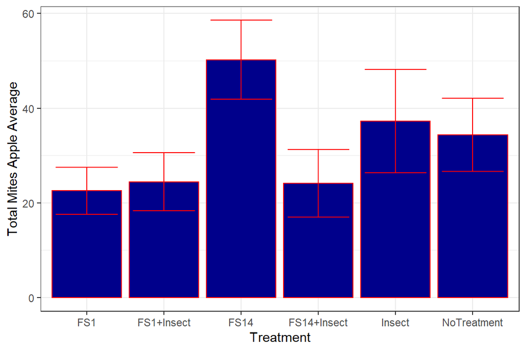

```r
##Boxplots
error_bars_total_mites_Apple <- ggplot(Mites_Apple,aes(treatment,total_mites))+
  geom_bar(fill="darkblue",stat = "summary",fun="mean",col="red")+xlab("Treatment")+
  geom_errorbar(stat='summary', width=0.8,position = "dodge",col="red")+
  theme_bw()+ylab("Total Mites Apple Average");error_bars_total_mites_Apple
```

```r
#Save plot
ggsave("error_bars_total_mites_Apple.tiff", units="in", width=10, height=5, dpi=300, compression = 'lzw')
```

From the visual comparison, it can be observed that the treatment `FS14` has the higher value Total Mites Apple as compared to all other treatments. Similarly, all the other differences can be assess by observing the visualization.

## 4: Comapring Mites Total Apple by Time.

Since, the experiment is conducted on two different time, and the the sample is same. Hence, the both sample can be considered as dependent or paired. For comparison between two paired samples, `Paired Sample T-Test` is widely used. The hypotheses for this test are presented below:

$H_0$: There is no difference in average Total Mites Apple by Time. $H_1$: There is a difference in average Total Mites Apple by Time.

```r
#Kruskal Wallis test
t_test1 <- t.test(total_mites~date_sampled,Mites_Apple,Paired=T)
#Reporting results
noquote("Results of Paired Sample T-Tes")
```

```
## [1] Results of Paired Sample T-Tes
```

```r
cat("T-Statistic =",10,"\n")
```

```
## T-Statistic = 10
```

```r
cat("Degree of Freedom =",222,"\n")
```

```
## Degree of Freedom = 222
```

```r
cat("Mean Mites Total (20 July) =", 80.24, "\n")
```

```
## Mean Mites Total (20 July) = 80.24
```

```r
cat("Mean Mites Total (26 July) =", 4.34, "\n")
```

```
## Mean Mites Total (26 July) = 4.34
```

```r
cat("P-value <","0.0001","\n")
```

```
## P-value < 0.0001
```